# Final Tutorial

### CMSC320 | Yash Sakharkar, Ishan Khillan, Soham Chawathe

## Introduction

### Motivation and Overview

Around the world, education has been a fundamental cornerstone of human society for thousands of years. Education is the reason why future generations learn valuable skills and why we are studying Computer Science at the University of Maryland. As such, education has influences on many aspects of life in the present and future. For instance, children need to be educated in order to obtain certain jobs in the future. How countries handle this may influence the rate at which children are employed in the future, increasing or decreasing unemployment rates. Education also helps with starting future economic and societal growth and developing new knowledge and research. Furthermore, the basic idea of education promotes equality because everyone, regardless of their background, should inherit the knowledge and opportunities to grow personally and professionally.

See below a similar study that we wanted to build off of using up-to-date data:

- https://www.jstor.org/stable/41613567 - 2012 Study by Earl Hunt from U.W. Seattle, linking genetics, economic development, culture, and education to a country's intelligence.

[figure not shown]

Several factors go into what makes a country’s education system unique. Mainly, it depends on the actual country. Typically, a country’s government allocates funds and resources to its education system in order to educate its youth. These funds are part of the country’s GDP, and depending on how those resources are distributed, they can greatly influence the type and amount a child is educated. Other factors impacting a country’s education system include literacy, completion, and enrollment rates. These metrics indicate how well a country’s education system is effective in a quantitative manner.

Acknowledging these factors it made us think: Does education affect IQ? For context, IQ (intelligence quotient) is a measure of human intelligence used to assess a person’s cognitive abilities. If that’s the case, which parts of education really play a factor in determining someone’s IQ? Could it be as simple as asking, “If a country puts more time and value into its education system, would that result in its citizens having higher IQs”? Wanting the answers to these questions, we decided to dedicate our Final Tutorial topic to the relationship between the factors of education systems and IQ.

This project aims to discover which factors related to education most significantly influence a person’s IQ through the Data Science lifecycle. Data collection and data processing will assist in obtaining as much relevant information as possible so that we can make reasonable claims about our data. Exploratory Data Analysis will help us discover the significance of relationships between factors such as unemployment, country location, etc, and how they could contribute to a person’s IQ. Then, we can analyze the data and conduct hypothesis testing to measure the significance of these relationships. Additionally, machine learning models, such as Linear Regression, Decision Trees, and Random Forests, will try to predict IQ based on some of these factors as independent variables. Lastly, we will provide recommendations on potential policy, future possibilities of continued research, and closing thoughts on our project.

[figure not shown]

### Preliminary Research

Before taking a data-oriented look into this topic, it was important for us to look into the factors that play into building a strong education system.

Here are some of the resources we read up on:

- https://theconversation.com/why-is-singapores-school-system-so-successful-and-is-it-a-model-for-the-west-22917 - Article by the Conversation on Singapore's educational success and philosophy
- http://spice.fsi.stanford.edu/docs/japanese_education - Stanford University's take on Japanese Education, its achievements, and how it differs from the American education we're used to
- https://www.smithsonianmag.com/innovation/why-are-finlands-schools-successful-49859555/ - An article by Smithsonian on the efficacy of Finland's individualized "whatever it takes" approach, honing in on students' weaknesses and ironing them out

## Data Collection + Processing

### Preliminary

Below, observe the following libraries which we will be using throughout this tutorial.

```python
import numpy as np
import pandas as pd
import matplotlib.pyplot as plt
import seaborn as sns
from selenium import webdriver
from bs4 import BeautifulSoup
import statsmodels.formula.api
from sklearn.model_selection import train_test_split
from sklearn.linear_model import LinearRegression
from sklearn.metrics import mean_squared_error
from sklearn.tree import DecisionTreeRegressor
from sklearn.tree import plot_tree
from sklearn.ensemble import RandomForestRegressor
import warnings
warnings.filterwarnings("ignore")
```

## Data Collection + Processing

### Dataset 1

#### Obtaining Data from CIA Website Through Webscraping

[figure not shown]

https://www.cia.gov/the-world-factbook/field/education-expenditures/country-comparison/

Here, we're trying to obtain data about the percentage of a country's GDP that goes towards education.

```python
#Here, we're using the Selenium library's Chrome Webdriver to webscrape the site's HTML content.
driver = webdriver.Chrome()
driver.get("https://www.cia.gov/the-world-factbook/field/education-expenditures/country-comparison/")
source_code = driver.page_source
```

```python
#Here we create BeautifulSoup object so we can extract relevant information.
bs = BeautifulSoup(source_code)
print(bs.prettify()[:1000]) #preview of page source
```

```
<html>
 <head>
  <meta charset="utf-8"/>
  <meta content="ie=edge" http-equiv="x-ua-compatible"/>
  <meta content="width=device-width, initial-scale=1, shrink-to-fit=no" name="viewport"/>
  <style id="typography.js">
   html{font-family:sans-serif;-ms-text-size-adjust:100%;-webkit-text-size-adjust:100%}body{margin:0}article,aside,details,figcaption,figure,footer,header,main,menu,nav,section,summary{display:block}audio,canvas,progress,video{display:inline-block}audio:not([controls]){display:none;height:0}progress…
```

```python
# all of the data we need is in table rows (tr tag)
tab = bs.findAll({"tr"})
```

```python
# get a sense of what the data from the table rows looks like
count = 0
for row in tab:
    print("Row: " + str(count))
    count += 1
    for entry in row:
        print(entry.get_text())

    if count == 5:
        break
```

```
Row: 0
Rank
Country
% of GDP
Date of Information
Row: 1
1
Marshall Islands
13.6
2020 est.
Row: 2
2
Solomon Islands
12.8
2020 est.
Row: 3
3
Kiribati
12.4
2019 est.
Row: 4
4
Greenland
10.2
2019 est.
```

```python
#here, we create gdp_df to house the data scraped from the site
gdp_df = pd.DataFrame(columns=['Rank', 'Country', 'Percent_GDP_Education', 'Date_of_Info'])

#each row in the table has multiple entries, for each of which we extract and store the text
for row in tab:
    lst = []
    for entry in row:
        lst.append(entry.get_text())
    # Add lst as a row to the DataFrame
    gdp_df.loc[len(gdp_df)] = lst

gdp_df.head()
```

|  | Rank | Country | Percent_GDP_Education | Date_of_Info |
| --- | --- | --- | --- | --- |
| 0 | Rank | Country | % of GDP | Date of Information |
| 1 | 1 | Marshall Islands | 13.6 | 2020 est. |
| 2 | 2 | Solomon Islands | 12.8 | 2020 est. |
| 3 | 3 | Kiribati | 12.4 | 2019 est. |
| 4 | 4 | Greenland | 10.2 | 2019 est. |

```python
#We don't need the Rank and Date_of_Info columns, so let's drop them in place
gdp_df.drop(0, axis=0, inplace=True)
gdp_df.drop(columns=['Rank', 'Date_of_Info'], inplace=True)
gdp_df.head()
```

|  | Country | Percent_GDP_Education |
| --- | --- | --- |
| 1 | Marshall Islands | 13.6 |
| 2 | Solomon Islands | 12.8 |
| 3 | Kiribati | 12.4 |
| 4 | Greenland | 10.2 |
| 5 | Bolivia | 9.8 |

We'll come back to this dataset later, when we merge it with the rest of our data.

## Data Collection + Processing

### Dataset 2

#### Obtaining Data from Kaggle's World Education Data:

https://www.kaggle.com/datasets/nelgiriyewithana/world-educational-data

Now, using the linked dataset above, we'll obtain data for Literacy Rates, Enrollment Rates, and other relevant World Education data.

```python
#Here, we read our data in from a csv using the Pandas library's read_csv function
education_df = pd.read_csv('Global_Education.csv', encoding='latin-1')
education_df.head()
```

|  | Countries and areas | Latitude | Longitude | OOSR_Pre0Primary_Age_Male | OOSR_Pre0Primary_Age_Female | OOSR_Primary_Age_Male | OOSR_Primary_Age_Female | OOSR_Lower_Secondary_Age_Male | OOSR_Lower_Secondary_Age_Female | OOSR_Upper_Secondary_Age_Male | ... | Primary_End_Proficiency_Reading | Primary_End_Proficiency_Math | Lower_Secondary_End_Proficiency_Reading | Lower_Secondary_End_Proficiency_Math | Youth_15_24_Literacy_Rate_Male | Youth_15_24_Literacy_Rate_Female | Birth_Rate | Gross_Primary_Education_Enrollment | Gross_Tertiary_Education_Enrollment | Unemployment_Rate |
| --- | --- | --- | --- | --- | --- | --- | --- | --- | --- | --- | --- | --- | --- | --- | --- | --- | --- | --- | --- | --- | --- |
| 0 | Afghanistan | 33.939110 | 67.709953 | 0 | 0 | 0 | 0 | 0 | 0 | 44 | ... | 13 | 11 | 0 | 0 | 74 | 56 | 32.49 | 104.0 | 9.7 | 11.12 |
| 1 | Albania | 41.153332 | 20.168331 | 4 | 2 | 6 | 3 | 6 | 1 | 21 | ... | 0 | 0 | 48 | 58 | 99 | 100 | 11.78 | 107.0 | 55.0 | 12.33 |
| 2 | Algeria | 28.033886 | 1.659626 | 0 | 0 | 0 | 0 | 0 | 0 | 0 | ... | 0 | 0 | 21 | 19 | 98 | 97 | 24.28 | 109.9 | 51.4 | 11.70 |
| 3 | Andorra | 42.506285 | 1.521801 | 0 | 0 | 0 | 0 | 0 | 0 | 0 | ... | 0 | 0 | 0 | 0 | 0 | 0 | 7.20 | 106.4 | 0.0 | 0.00 |
| 4 | Angola | 11.202692 | 17.873887 | 31 | 39 | 0 | 0 | 0 | 0 | 0 | ... | 0 | 0 | 0 | 0 | 0 | 0 | 40.73 | 113.5 | 9.3 | 6.89 |

5 rows × 29 columns

#### Let's clean up this data. Note that we won't be using the following columns, so we'll drop them:

'OOSR_Pre0Primary_Age_Male', 'OOSR_Pre0Primary_Age_Female', 'OOSR_Primary_Age_Male', 'OOSR_Primary_Age_Female', 'OOSR_Lower_Secondary_Age_Male', 'OOSR_Lower_Secondary_Age_Female', 'OOSR_Upper_Secondary_Age_Male', 'OOSR_Upper_Secondary_Age_Female', 'Completion_Rate_Primary_Male', 'Completion_Rate_Primary_Female', 'Completion_Rate_Lower_Secondary_Male', 'Completion_Rate_Lower_Secondary_Female', 'Grade_2_3_Proficiency_Reading', 'Grade_2_3_Proficiency_Math', 'Primary_End_Proficiency_Reading', 'Primary_End_Proficiency_Math', 'Lower_Secondary_End_Proficiency_Reading', 'Lower_Secondary_End_Proficiency_Math'

```python
education_df.drop(columns=['OOSR_Pre0Primary_Age_Male', 'OOSR_Pre0Primary_Age_Female', 'OOSR_Primary_Age_Male',
                 'OOSR_Primary_Age_Female', 'OOSR_Lower_Secondary_Age_Male', 'OOSR_Lower_Secondary_Age_Female',
                 'OOSR_Upper_Secondary_Age_Male', 'OOSR_Upper_Secondary_Age_Female', 'Completion_Rate_Primary_Male',
                 'Completion_Rate_Primary_Female', 'Completion_Rate_Lower_Secondary_Male',
                 'Completion_Rate_Lower_Secondary_Female', 'Grade_2_3_Proficiency_Reading',
                 'Grade_2_3_Proficiency_Math', 'Primary_End_Proficiency_Reading', 'Primary_End_Proficiency_Math',
                 'Lower_Secondary_End_Proficiency_Reading', 'Lower_Secondary_End_Proficiency_Math'], inplace=True)
```

```python
#Sao Tome and Principe had some special characters, so we manually restore it to a legible form
education_df.loc[155, 'Countries and areas'] = 'Sao Tome and Principe'
education_df.head()
```

|  | Countries and areas | Latitude | Longitude | Completion_Rate_Upper_Secondary_Male | Completion_Rate_Upper_Secondary_Female | Youth_15_24_Literacy_Rate_Male | Youth_15_24_Literacy_Rate_Female | Birth_Rate | Gross_Primary_Education_Enrollment | Gross_Tertiary_Education_Enrollment | Unemployment_Rate |
| --- | --- | --- | --- | --- | --- | --- | --- | --- | --- | --- | --- |
| 0 | Afghanistan | 33.939110 | 67.709953 | 32 | 14 | 74 | 56 | 32.49 | 104.0 | 9.7 | 11.12 |
| 1 | Albania | 41.153332 | 20.168331 | 76 | 80 | 99 | 100 | 11.78 | 107.0 | 55.0 | 12.33 |
| 2 | Algeria | 28.033886 | 1.659626 | 22 | 37 | 98 | 97 | 24.28 | 109.9 | 51.4 | 11.70 |
| 3 | Andorra | 42.506285 | 1.521801 | 0 | 0 | 0 | 0 | 7.20 | 106.4 | 0.0 | 0.00 |
| 4 | Angola | 11.202692 | 17.873887 | 24 | 15 | 0 | 0 | 40.73 | 113.5 | 9.3 | 6.89 |

We want to classify by continent as well for our later Exploratory Data Analysis, so we'll do that using a continent dataset, found here:

https://www.kaggle.com/datasets/hserdaraltan/countries-by-continent

```python
#As with before, we read the csv into a dataframe using Pandas' read_csv function
continent_df = pd.read_csv('Continents.csv')
continent_df.head()
```

|  | Continent | Country |
| --- | --- | --- |
| 0 | Africa | Algeria |
| 1 | Africa | Angola |
| 2 | Africa | Benin |
| 3 | Africa | Botswana |
| 4 | Africa | Burkina |

We'll now do a left join of the two tables so we accordingly assign continent to country in our education_df. The reason for a left join is that we definitely want the education data, and can fill in any missing continent entries manually.

```python
education_df.rename(columns={'Countries and areas':'Country', 'Latitude ':'Latitude'}, inplace=True)
education_continent_df = education_df.merge(continent_df, how='left', on='Country')

#The following code is just meant to move the Continent column from the end to the first column
#We simply create a list of all the columns in the order we want and feed it into our merged dataframe
reordered = ['Country',
            'Continent',
            'Latitude',
            'Longitude',
            'Completion_Rate_Upper_Secondary_Male',
            'Completion_Rate_Upper_Secondary_Female',
            'Youth_15_24_Literacy_Rate_Male',
            'Youth_15_24_Literacy_Rate_Female',
            'Birth_Rate',
            'Gross_Primary_Education_Enrollment',
            'Gross_Tertiary_Education_Enrollment',
            'Unemployment_Rate'
            ]
education_continent_df = education_continent_df[reordered]
```

Observe in the below 3 cell(s) we identify and successfully update rows containing missing data under the Continent column

```python
education_continent_df[education_continent_df['Continent'].isna()]
```

|  | Country | Continent | Latitude | Longitude | Completion_Rate_Upper_Secondary_Male | Completion_Rate_Upper_Secondary_Female | Youth_15_24_Literacy_Rate_Male | Youth_15_24_Literacy_Rate_Female | Birth_Rate | Gross_Primary_Education_Enrollment | Gross_Tertiary_Education_Enrollment | Unemployment_Rate |
| --- | --- | --- | --- | --- | --- | --- | --- | --- | --- | --- | --- | --- |
| 5 | Anguilla | NaN | 18.220554 | 63.068615 | 0 | 0 | 0 | 0 | 0.00 | 0.0 | 0.0 | 0.00 |
| 12 | The Bahamas | NaN | 25.034280 | 77.396280 | 0 | 0 | 0 | 0 | 13.97 | 81.4 | 15.1 | 10.36 |
| 25 | British Virgin Islands | NaN | 18.420695 | 64.639968 | 0 | 0 | 0 | 0 | 0.00 | 0.0 | 0.0 | 0.00 |
| 28 | Burkina Faso | NaN | 12.238333 | 1.561593 | 6 | 2 | 62 | 55 | 37.93 | 96.1 | 6.5 | 6.26 |
| 40 | Republic of the Congo | NaN | 0.228021 | 15.827659 | 28 | 19 | 85 | 79 | 32.86 | 106.6 | 12.7 | 9.47 |
| 41 | Cook Islands | NaN | 21.236736 | 159.777671 | 0 | 0 | 0 | 0 | 0.00 | 0.0 | 0.0 | 0.00 |
| 47 | Czech Republic | NaN | 49.817492 | 15.472962 | 0 | 0 | 0 | 0 | 10.70 | 100.7 | 64.1 | 1.93 |
| 49 | Democratic Republic of the Congo | NaN | 4.038333 | 21.758664 | 36 | 27 | 0 | 0 | 41.18 | 108.0 | 6.6 | 4.24 |
| 60 | Eswatini | NaN | 26.522503 | 31.465866 | 31 | 33 | 94 | 97 | 0.00 | 0.0 | 0.0 | 0.00 |
| 66 | The Gambia | NaN | 13.443182 | 15.310139 | 33 | 28 | 0 | 0 | 38.54 | 98.0 | 2.7 | 9.06 |
| 74 | Guinea0Bissau | NaN | 11.803749 | 15.180413 | 14 | 8 | 0 | 0 | 35.13 | 118.7 | 2.6 | 2.47 |
| 85 | Republic of Ireland | NaN | 53.412910 | 8.243890 | 0 | 0 | 0 | 0 | 12.50 | 100.9 | 77.8 | 4.93 |
| 115 | Federated States of Micronesia | NaN | 7.425554 | 150.550812 | 0 | 0 | 0 | 0 | 22.82 | 97.2 | 14.1 | 0.00 |
| 119 | Montserrat | NaN | 16.742498 | 62.187366 | 0 | 0 | 0 | 0 | 0.00 | 0.0 | 0.0 | 0.00 |
| 122 | Myanmar | NaN | 21.916221 | 95.955974 | 14 | 19 | 0 | 0 | 17.55 | 112.3 | 18.8 | 1.58 |
| 131 | Niue | NaN | 19.054445 | 169.867233 | 0 | 0 | 0 | 0 | 0.00 | 0.0 | 0.0 | 0.00 |
| 132 | North Macedonia | NaN | 41.608635 | 21.745275 | 86 | 79 | 0 | 0 | 0.00 | 0.0 | 0.0 | 0.00 |
| 170 | Palestinian National Authority | NaN | 31.952162 | 35.233154 | 52 | 73 | 99 | 99 | 0.00 | 0.0 | 0.0 | 0.00 |
| 180 | Tokelau | NaN | 9.200200 | 171.848400 | 0 | 0 | 0 | 0 | 0.00 | 0.0 | 0.0 | 0.00 |
| 186 | Turks and Caicos Islands | NaN | 21.694025 | 71.797928 | 0 | 0 | 0 | 0 | 0.00 | 0.0 | 0.0 | 0.00 |

```python
education_continent_df.loc[5,'Continent'] = 'North America'
education_continent_df.loc[12, 'Continent'] = 'North America'
education_continent_df.loc[25, 'Continent'] = 'North America'
education_continent_df.loc[28, 'Continent'] = 'Africa'
education_continent_df.loc[40, 'Continent'] = 'Africa'
education_continent_df.loc[41, 'Continent'] = 'Oceania'
education_continent_df.loc[47, 'Continent'] = 'Europe'
education_continent_df.loc[49, 'Continent'] = 'Africa'
education_continent_df.loc[60, 'Continent'] = 'Africa'
education_continent_df.loc[66, 'Continent'] = 'Africa'
education_continent_df.loc[74, 'Continent'] = 'Africa'
education_continent_df.loc[85, 'Continent'] = 'Europe'
education_continent_df.loc[115, 'Continent'] = 'Oceania'
education_continent_df.loc[119, 'Continent'] = 'North America'
education_continent_df.loc[122, 'Continent'] = 'Asia'
education_continent_df.loc[131, 'Continent'] = 'Oceania'
education_continent_df.loc[132, 'Continent'] = 'Europe'
education_continent_df.loc[170, 'Continent'] = 'Asia'
education_continent_df.loc[180, 'Continent'] = 'Oceania'
education_continent_df.loc[186, 'Continent'] = 'North America'
```

```python
education_continent_df[education_continent_df['Continent'].isna()] #observe there is no more missing continent data.
```

|  | Country | Continent | Latitude | Longitude | Completion_Rate_Upper_Secondary_Male | Completion_Rate_Upper_Secondary_Female | Youth_15_24_Literacy_Rate_Male | Youth_15_24_Literacy_Rate_Female | Birth_Rate | Gross_Primary_Education_Enrollment | Gross_Tertiary_Education_Enrollment | Unemployment_Rate |
| --- | --- | --- | --- | --- | --- | --- | --- | --- | --- | --- | --- | --- |

#### Merging the GDP and World Education Datasets

Once again, observe that we conduct a left join for the same reason stated above.

```python
gdp_education = education_continent_df.merge(gdp_df, how='left', on='Country')
gdp_education.head()
```

|  | Country | Continent | Latitude | Longitude | Completion_Rate_Upper_Secondary_Male | Completion_Rate_Upper_Secondary_Female | Youth_15_24_Literacy_Rate_Male | Youth_15_24_Literacy_Rate_Female | Birth_Rate | Gross_Primary_Education_Enrollment | Gross_Tertiary_Education_Enrollment | Unemployment_Rate | Percent_GDP_Education |
| --- | --- | --- | --- | --- | --- | --- | --- | --- | --- | --- | --- | --- | --- |
| 0 | Afghanistan | Asia | 33.939110 | 67.709953 | 32 | 14 | 74 | 56 | 32.49 | 104.0 | 9.7 | 11.12 | 2.9 |
| 1 | Albania | Europe | 41.153332 | 20.168331 | 76 | 80 | 99 | 100 | 11.78 | 107.0 | 55.0 | 12.33 | 3.1 |
| 2 | Algeria | Africa | 28.033886 | 1.659626 | 22 | 37 | 98 | 97 | 24.28 | 109.9 | 51.4 | 11.70 | 7 |
| 3 | Andorra | Europe | 42.506285 | 1.521801 | 0 | 0 | 0 | 0 | 7.20 | 106.4 | 0.0 | 0.00 | 2.9 |
| 4 | Angola | Africa | 11.202692 | 17.873887 | 24 | 15 | 0 | 0 | 40.73 | 113.5 | 9.3 | 6.89 | 2.4 |

Below, we're identifying and fixing rows for which we have NaN under the Percent_GDP_Education column.

```python
gdp_education[gdp_education['Percent_GDP_Education'].isna()][['Country', 'Percent_GDP_Education']]
```

|  | Country | Percent_GDP_Education |
| --- | --- | --- |
| 12 | The Bahamas | NaN |
| 22 | Bosnia and Herzegovina | NaN |
| 30 | Cape Verde | NaN |
| 40 | Republic of the Congo | NaN |
| 43 | Ivory Coast | NaN |
| 45 | Cuba | NaN |
| 47 | Czech Republic | NaN |
| 48 | North Korea | NaN |
| 49 | Democratic Republic of the Congo | NaN |
| 57 | Equatorial Guinea | NaN |
| 58 | Eritrea | NaN |
| 66 | The Gambia | NaN |
| 74 | Guinea0Bissau | NaN |
| 77 | Vatican City | NaN |
| 85 | Republic of Ireland | NaN |
| 101 | Libya | NaN |
| 115 | Federated States of Micronesia | NaN |
| 118 | Montenegro | NaN |
| 122 | Myanmar | NaN |
| 131 | Niue | NaN |
| 132 | North Macedonia | NaN |
| 145 | South Korea | NaN |
| 170 | Palestinian National Authority | NaN |
| 171 | Sudan | NaN |
| 175 | Syria | NaN |
| 178 | East Timor | NaN |
| 180 | Tokelau | NaN |
| 184 | Turkey | NaN |
| 187 | Tuvalu | NaN |
| 199 | Yemen | NaN |

```python
gdp_education.loc[12, 'Percent_GDP_Education'] = 2.8
gdp_education.loc[30, 'Percent_GDP_Education'] = 7.6
gdp_education.loc[40, 'Percent_GDP_Education'] = 4.5
gdp_education.loc[43, 'Percent_GDP_Education'] = 3.4
gdp_education.loc[47, 'Percent_GDP_Education'] = 5.1
gdp_education.loc[49, 'Percent_GDP_Education'] = 2.7
gdp_education.loc[66, 'Percent_GDP_Education'] = 2.8
gdp_education.loc[74, 'Percent_GDP_Education'] = 2.7
gdp_education.loc[85, 'Percent_GDP_Education'] = 3.1
gdp_education.loc[115, 'Percent_GDP_Education'] = 9.7
gdp_education.loc[122, 'Percent_GDP_Education'] = 2.1
gdp_education.loc[145, 'Percent_GDP_Education'] = 4.7
gdp_education.loc[170, 'Percent_GDP_Education'] = 5.3
gdp_education.loc[178, 'Percent_GDP_Education'] = 4.2
gdp_education.loc[184, 'Percent_GDP_Education'] = 3.4
```

```python
#Now, we identify the countries for which we did not have GDP Data
gdp_education[gdp_education['Percent_GDP_Education'].isna()][['Country', 'Percent_GDP_Education']]
```

|  | Country | Percent_GDP_Education |
| --- | --- | --- |
| 22 | Bosnia and Herzegovina | NaN |
| 45 | Cuba | NaN |
| 48 | North Korea | NaN |
| 57 | Equatorial Guinea | NaN |
| 58 | Eritrea | NaN |
| 77 | Vatican City | NaN |
| 101 | Libya | NaN |
| 118 | Montenegro | NaN |
| 131 | Niue | NaN |
| 132 | North Macedonia | NaN |
| 171 | Sudan | NaN |
| 175 | Syria | NaN |
| 180 | Tokelau | NaN |
| 187 | Tuvalu | NaN |
| 199 | Yemen | NaN |

```python
#We'll proceed to drop the corresponding rows by the indices identified above
gdp_education.drop([22, 45, 48, 57, 58, 77, 101, 118, 131, 132, 171, 175, 180, 187, 199], inplace=True)
#Reset indices accordingly
gdp_education.reset_index(drop=True, inplace=True)
```

```python
#Observe we have no more missing data under the Percent GDP Education column
gdp_education[gdp_education['Percent_GDP_Education'].isna()][['Country', 'Percent_GDP_Education']]
```

|  | Country | Percent_GDP_Education |
| --- | --- | --- |

## Data Collection + Processing

### Dataset 3

#### Obtaining Data on IQ by Country from another Dataset

[figure not shown]

https://www.datapandas.org/ranking/average-iq-by-country

Now, we proceed to merge our 3rd dataset, which holds IQ by Country

```python
iq_df = pd.read_csv('countries-by-iq----average-iq-by-country-2024.csv')

#Here, we drop data that we will not be using (everything aside from IQ)
iq_df.drop(len(iq_df) - 1, inplace=True)
iq_df.drop(columns=['averageIqByCountry_sourceLynnBecker2019', 'AverageIQ_ICI2017Grade', 'AverageIQ_ICI2017Score', 'OverallPisaScore2022', 'PISAScoresMathScore2022', 'PISAScoresScienceScore2022', 'PISAScoresReadingScore2022'], inplace=True)
iq_df.rename(columns={'averageIqByCountry_iqLynnBecker2019': 'IQ', 'country':'Country'}, inplace=True)
iq_df.sort_values(by='IQ', ascending=False, inplace=True)
iq_df.head()
```

|  | Country | IQ |
| --- | --- | --- |
| 11 | Japan | 106.48 |
| 58 | Taiwan | 106.47 |
| 113 | Singapore | 105.89 |
| 103 | Hong Kong | 105.37 |
| 1 | China | 104.10 |

```python
#Again, we left join for the same reasons as above.
composite_df = gdp_education.merge(iq_df, how='left', on='Country')
```

As with our prior merges, we clean up missing data by fixing rows for which we can find data and removing those for which we cannot.

```python
composite_df[composite_df['IQ'].isna()][['Country', 'IQ']]
```

|  | Country | IQ |
| --- | --- | --- |
| 5 | Anguilla | NaN |
| 12 | The Bahamas | NaN |
| 46 | Democratic Republic of the Congo | NaN |
| 61 | The Gambia | NaN |
| 69 | Guinea0Bissau | NaN |
| 79 | Republic of Ireland | NaN |
| 108 | Federated States of Micronesia | NaN |
| 109 | Monaco | NaN |
| 111 | Montserrat | NaN |
| 116 | Nauru | NaN |
| 126 | Palau | NaN |
| 144 | San Marino | NaN |
| 160 | Palestinian National Authority | NaN |
| 166 | East Timor | NaN |
| 169 | Trinidad and Tobago | NaN |

```python
composite_df.loc[12, 'IQ'] = 86.99
composite_df.loc[46, 'IQ'] = 64.92
composite_df.loc[61, 'IQ'] = 52.68
composite_df.loc[79, 'IQ'] = 95.13
composite_df.loc[108, 'IQ'] = 83.96
composite_df.loc[160, 'IQ'] = 77.69
```

```python
#Below are those for which we do not have IQ data to fill in
composite_df[composite_df['IQ'].isna()][['Country', 'IQ']]
```

|  | Country | IQ |
| --- | --- | --- |
| 5 | Anguilla | NaN |
| 69 | Guinea0Bissau | NaN |
| 109 | Monaco | NaN |
| 111 | Montserrat | NaN |
| 116 | Nauru | NaN |
| 126 | Palau | NaN |
| 144 | San Marino | NaN |
| 166 | East Timor | NaN |
| 169 | Trinidad and Tobago | NaN |

```python
#Observe that we no longer have any NaN data under the IQ column after the execution of this cell
composite_df.drop([5, 69, 109, 111, 116, 126, 144, 166, 169], inplace=True)
composite_df.reset_index(drop=True, inplace=True)
composite_df[composite_df['IQ'].isna()][['Country', 'IQ']]
```

|  | Country | IQ |
| --- | --- | --- |

```python
composite_df.head(5)
```

|  | Country | Continent | Latitude | Longitude | Completion_Rate_Upper_Secondary_Male | Completion_Rate_Upper_Secondary_Female | Youth_15_24_Literacy_Rate_Male | Youth_15_24_Literacy_Rate_Female | Birth_Rate | Gross_Primary_Education_Enrollment | Gross_Tertiary_Education_Enrollment | Unemployment_Rate | Percent_GDP_Education | IQ |
| --- | --- | --- | --- | --- | --- | --- | --- | --- | --- | --- | --- | --- | --- | --- |
| 0 | Afghanistan | Asia | 33.939110 | 67.709953 | 32 | 14 | 74 | 56 | 32.49 | 104.0 | 9.7 | 11.12 | 2.9 | 82.12 |
| 1 | Albania | Europe | 41.153332 | 20.168331 | 76 | 80 | 99 | 100 | 11.78 | 107.0 | 55.0 | 12.33 | 3.1 | 81.75 |
| 2 | Algeria | Africa | 28.033886 | 1.659626 | 22 | 37 | 98 | 97 | 24.28 | 109.9 | 51.4 | 11.70 | 7 | 76.00 |
| 3 | Andorra | Europe | 42.506285 | 1.521801 | 0 | 0 | 0 | 0 | 7.20 | 106.4 | 0.0 | 0.00 | 2.9 | 95.20 |
| 4 | Angola | Africa | 11.202692 | 17.873887 | 24 | 15 | 0 | 0 | 40.73 | 113.5 | 9.3 | 6.89 | 2.4 | 75.10 |

We will now proceed to conduct Exploratory Data Analysis on our accumulated data.

## Exploratory Data Analysis

[figure not shown]

[figure not shown]

Below, we'll generate a violinplot to observe the distribution of IQ spent on education by Continent. Each "Violin" is a distribution turned on its side of all the countries in said continent.

```python
#Here we convert the "Percents" to decimals
composite_df['Percent_GDP_Education'] = [float(elt)/100 for elt in composite_df['Percent_GDP_Education']]
```

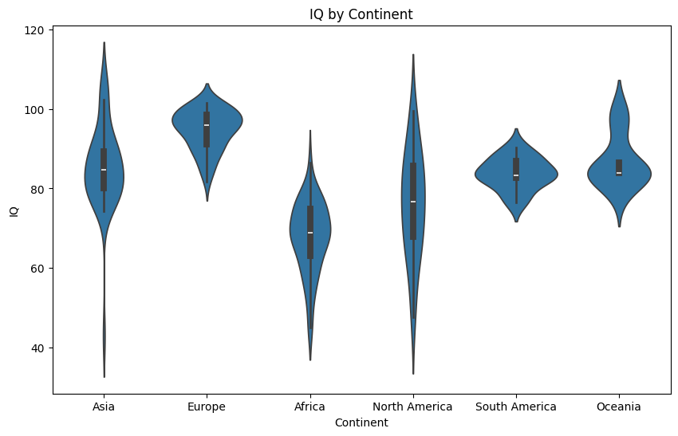

```python
plt.figure(figsize=(10,6))
#Violin plot with continent on the x-axis and IQ on the y-axis
sns.violinplot(x='Continent', y='IQ', data = composite_df)
plt.xlabel('Continent')
plt.ylabel('IQ')
plt.title('IQ by Continent')
plt.show()
```

Interpreting this can be a little confusing, as it doesn't clearly tell us whether there's a dependence on continent, i.e. neighboring countries, on IQ. We could interpret it as there being a dependence for all continents excluding Asia and North America, but even this is unclear.

## Exploratory Data Analysis

### Graph 2: Scatter Plot of IQ vs Percent GDP Spent on Education

Below, we'll create a scatter plot with Percent GDP on the x-axis, and IQ on the y-axis.

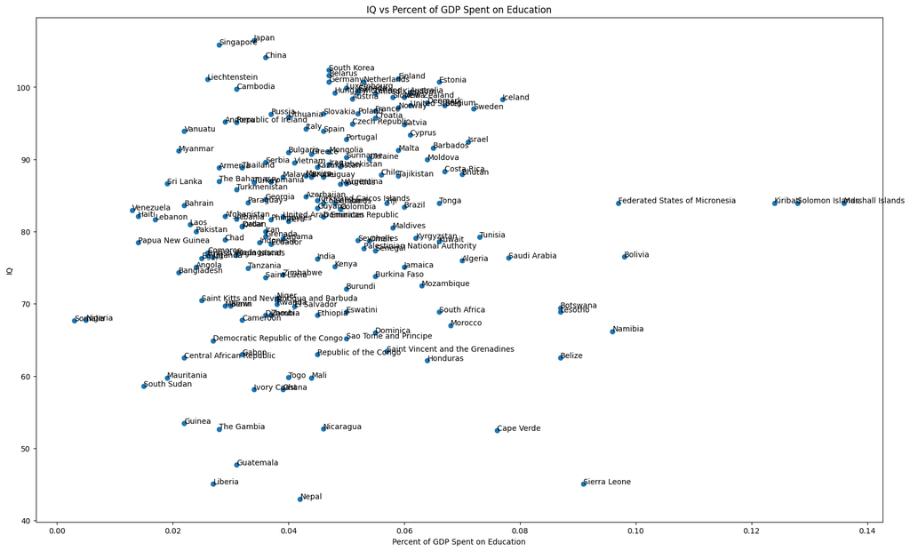

```python
plt.figure(figsize=(20,12))
plt.scatter(composite_df['Percent_GDP_Education'], composite_df['IQ'])

#Below, for each point  in our scatter plot we add a label (the country name)
for country in composite_df['Country']:
    plt.annotate(country, (composite_df[composite_df['Country'] == country]['Percent_GDP_Education'],
                           composite_df[composite_df['Country'] == country]['IQ']))

plt.xlabel('Percent of GDP Spent on Education')
plt.ylabel('IQ')
plt.title('IQ vs Percent of GDP Spent on Education')
plt.show()
```

Above, we've successfully generated our scatterplot. A preliminary observation suggests there isn't a relationship between IQ and Percent of GDP, or even if there is, there doesn't appear to be a very strong one. We'll take a more analytical look at this idea again in our ML section when we attempt to fit Regression models to the data.

For now, let's see if separating the data by continent makes a difference.

## Exploratory Data Analysis

### Graph 3: Scatter Plots of IQ vs Percent GDP Spent on Education by Continent

Below, we'll create scatterplots in a similar manner, but separate them by continent and observe if there appears to be a dependence by continent.

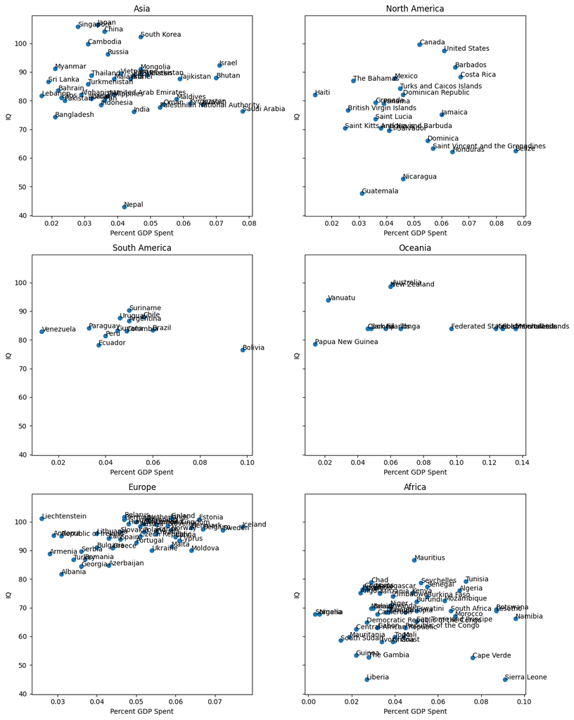

```python
continents = list(set(composite_df['Continent']))

#Here we'll use subplots to separate by continent
fig, axs = plt.subplots(3, 2, figsize=(12,15), sharey=True)

#For each continent, we plot and label its data on the corresponding subplot
for i, continent in enumerate(continents):
    #counters for row and column
    row = i // 2
    col = i % 2

    #Here we filter by just the continent we're currently examining
    c = composite_df[composite_df['Continent'] == continent]
    #For that given continent, we generate a scatterplot with Percent_GDP_Education
    #on the x-axis, and IQ on the y-axis
    axs[row, col].scatter(c['Percent_GDP_Education'], c['IQ'])
    axs[row, col].set_title(f'{continent}')
    axs[row, col].set_xlabel('Percent GDP Spent')
    axs[row, col].set_ylabel('IQ')

    #Now, within the subplot, we label each point with its country
    for country in c['Country']:
        axs[row,col].annotate(country, (c[c['Country'] == country]['Percent_GDP_Education'],
                           c[c['Country'] == country]['IQ']))

plt.tight_layout()
plt.show()
```

We observe that primarily for Europe, there appears to be a positive trend between the Percent GDP Spent on Education and IQ. We can observe the same for Africa, though it is not as strong a correlation. Asia too appears to have a linear correlation, though not positive, but rather stagnant (horizontal line), with a 0 slope. The presence or lack thereof of a correlation is hard to identify for the Oceania, North America, and South America graphs.

## Exploratory Data Analysis

### Graph 4: Scatter Plots of IQ vs Gross Primary and Tertiary Education Enrollment Rates

[figure not shown]

We'll create scatter plots of IQ vs Gross Education Enrollment Rates in similar fashion as above.

Gross Primary and Tertiary Education Enrollment Rates are defined as the percentage of the corresponding age groups that are enrolled in their respective education system. That is, for example, primary education usually spans ages 6-11, so the metric will calculate out of all people in the country aged 6-11, what percentage are enrolled in primary education? Hence, it's an important metric to show how accessible all levels of education are in a country and how that accessibility might affect the intelligence of its population.

Unfortunately, there is some missing data (see below) for gross primary and tertiary education enrollment (we will assume 0% means missing data). But, there are not too many of these so we can graph just the rows with data and still get a great idea of any correlation.

```python
print(f'Missing for Primary: {len(composite_df[composite_df["Gross_Primary_Education_Enrollment"] == 0])}')
print(f'Missing for Tertiary: {len(composite_df[composite_df["Gross_Tertiary_Education_Enrollment"] == 0])}')
```

```
Missing for Primary: 5
Missing for Tertiary: 10
```

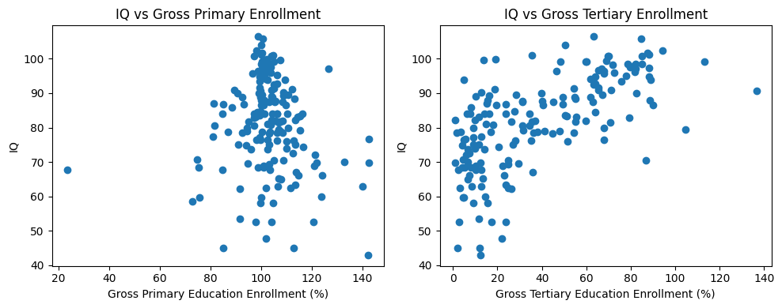

```python
# 2 subplots - one for gross primary and one for gross secondary
fig, axes = plt.subplots(1, 2, figsize=(10, 4))

# only plotting non-zero rows
axes[0].scatter(composite_df[composite_df['Gross_Primary_Education_Enrollment'] != 0]['Gross_Primary_Education_Enrollment'], composite_df[composite_df['Gross_Primary_Education_Enrollment'] != 0]['IQ'])
axes[0].set_title('IQ vs Gross Primary Enrollment')
axes[0].set_xlabel('Gross Primary Education Enrollment (%)')
axes[0].set_ylabel('IQ')

# only plotting non-zero rows
axes[1].scatter(composite_df[composite_df['Gross_Tertiary_Education_Enrollment'] != 0]['Gross_Tertiary_Education_Enrollment'], composite_df[composite_df['Gross_Tertiary_Education_Enrollment'] != 0]['IQ'])
axes[1].set_title('IQ vs Gross Tertiary Enrollment')
axes[1].set_xlabel('Gross Tertiary Education Enrollment (%)')
axes[1].set_ylabel('IQ')

plt.tight_layout()
plt.show()
```

These two graphs are interesting.

For gross primary enrollment, it seems as though after gross primary enrollment has reached a certain point, there is no longer any correlation to the IQ -- around the 100% enrollment rate, the IQ ranges all the way from 45 to above a 100.

However, with tertiary enrollment, there does seem to a solid positive correlation -- as gross tertiary education enrollment increases, the IQ of the country's population seems to increase as well. This relation does not seem linear, though as it grows much faster from enrollment rates 0% to 40% than it does after that.

## Exploratory Data Analysis

### Graph 5: Scatter Plot of IQ vs Upper Secondary Education Completion Rates

[figure not shown]

As noted above, enrollment in tertiary education seems to have a correlation to the intelligence of the population. So now let's look into the correlation with completing what comes before tertiary education (i.e. upper secondary education) and how that affects IQ. We should expect that higher completion rates of upper secondary education would also mean higher IQ and that these two should be correlated because more people completing upper secondary education should mean more people enroll in tertiary education.

We'll create scatter plots in the same way for upper secondary education completion rates with the caveat that there are female and male rates, so we need to average these two into one column before graphing.

```python
# first let's average out the male and female completion rate columns and create a new column
mean_completion_rates = composite_df[['Completion_Rate_Upper_Secondary_Male', 'Completion_Rate_Upper_Secondary_Female']].mean(axis=1)

# we want to insert these entries into 1 column after the female completion rates for ease of reading
insert_index = composite_df.columns.get_loc('Completion_Rate_Upper_Secondary_Female') + 1
composite_df.insert(insert_index, 'Completion_Rate_Upper_Secondary_Average', mean_completion_rates)
```

As we can see below, there are some rows with missing data (0% completion rates), we will graph without these. Unforunately, there are 80 such countries, which is 45% of all of our data, but it will be good to still visualize the countries for which we do have this data.

```python
len(composite_df[composite_df['Completion_Rate_Upper_Secondary_Average'] == 0])
```

```
80
```

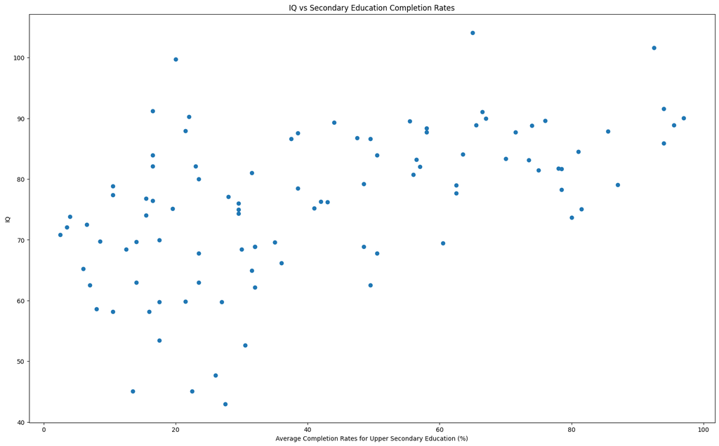

```python
plt.figure(figsize=(20,12))

# only plot the rows for which we have data (non-zero completion rates)
plt.scatter(composite_df[composite_df['Completion_Rate_Upper_Secondary_Average'] != 0]['Completion_Rate_Upper_Secondary_Average'], composite_df[composite_df['Completion_Rate_Upper_Secondary_Average'] != 0]['IQ'])
plt.xlabel('Average Completion Rates for Upper Secondary Education (%)')
plt.ylabel('IQ')
plt.title('IQ vs Secondary Education Completion Rates')
plt.show()
```

As we expected, there is a positive correlation between upper secondary education completion and IQ. Hence, more people in the country completing an upper secondary education seems to mean the country has higher average IQs. This correlation also seems linear in nature.

## Exploratory Data Analysis

### Graph 6: Scatter Plot of Gross Tertiary Enrollment vs Upper Secondary Education Completion Rates

[figure not shown]

So, if countries with more people completing their upper secondary education are smarter and those with higher enrollments in tertiary education (which follows upper secondary) are also smarter, does that mean that those countries with more people completing upper secondary education just send more people to tertiary education? That would make sense, so let's explore that.

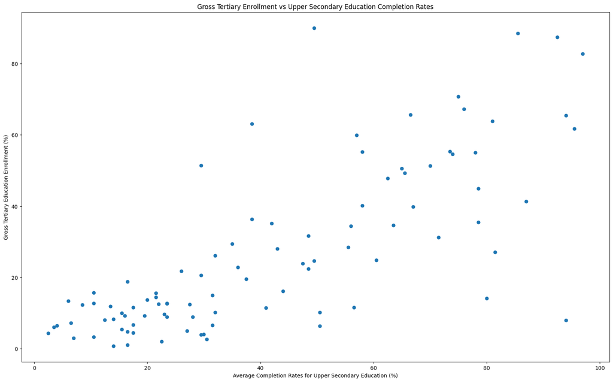

```python
plt.figure(figsize=(20,12))

# only plot the rows for which we have data (non-zero completion rates)
plt.scatter(composite_df[(composite_df['Completion_Rate_Upper_Secondary_Average'] != 0) & (composite_df['Gross_Tertiary_Education_Enrollment'] != 0)]['Completion_Rate_Upper_Secondary_Average'], composite_df[(composite_df['Completion_Rate_Upper_Secondary_Average'] != 0) & (composite_df['Gross_Tertiary_Education_Enrollment'] != 0)]['Gross_Tertiary_Education_Enrollment'])
plt.xlabel('Average Completion Rates for Upper Secondary Education (%)')
plt.ylabel('Gross Tertiary Education Enrollment (%)')
plt.title('Gross Tertiary Enrollment vs Upper Secondary Education Completion Rates')
plt.show()
```

As we expected, those countries with higher upper secondary completion rates have higher enrollments in tertiary education. The correlation is strong and seems linear in nature. This begs the question: is completion rates for upper secondary education a metric that even matters then? Or would it just be gross tertiary enrollment rates that explain IQ in these countries? We will explore this in the ML section.

## Exploratory Data Analysis

### Graph 7: Scatter Plot of IQ vs Unemployment Rate

Now let's analyze how a country's unemployment rate could influence its IQ. An initial claim that we could make is that as unemployment rates increase, IQ decreases because citizens of countries with lower unemployment rates should have jobs, some of which require a good IQ in order to fulfill the job.

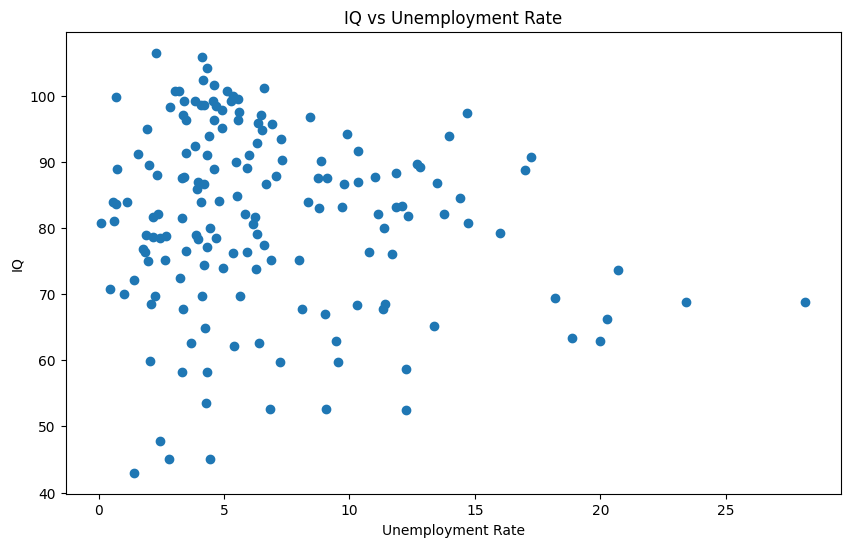

```python
plt.figure(figsize=(10,6))

# only include and plot countries where the unemployment rate data exists (not equal to 0)
nonzero_unemployment_countries = composite_df[composite_df['Unemployment_Rate'] != 0]
plt.scatter(nonzero_unemployment_countries['Unemployment_Rate'], nonzero_unemployment_countries['IQ'])

plt.xlabel('Unemployment Rate')
plt.ylabel('IQ')
plt.title('IQ vs Unemployment Rate')
plt.show()
```

However, let's check how the percent of GDP spent on education could also influence a country's unemployment rate.

## Exploratory Data Analysis

### Graph 8: Scatter Plot of Unemployment Rate vs. Percent of GDP Spent on Education

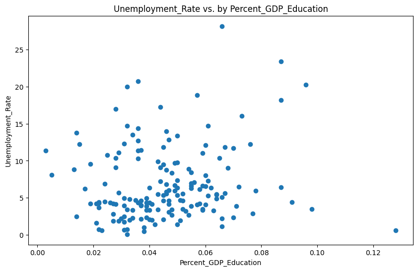

```python
plt.figure(figsize=(10,6))

# only include and plot countries where the unemployment rate data exists (not equal to 0)
nonzero_unemployment_countries = composite_df[composite_df['Unemployment_Rate'] != 0]
plt.scatter(nonzero_unemployment_countries['Percent_GDP_Education'], nonzero_unemployment_countries['Unemployment_Rate'])

plt.xlabel('Percent_GDP_Education')
plt.ylabel('Unemployment_Rate')
plt.title('Unemployment_Rate vs. by Percent_GDP_Education')
plt.show()
```

## Exploratory Data Analysis

### Graph 9: Violin Plot of IQs and Unemployment Rates for Countries with Upper Secondary Education Completion Discrepancies between Genders

Finally, let's pivot to looking at whether a country's ability to educate both genders equally is affecting how intellectual its population is/how much of it is employed. As can be seen in the article below, gender disparities in education is directly linked to issues in development and economic growth.

- https://www.jstor.org/stable/3990191 - 2002 Study that explores how populations with greater educational inequality lead to birth rates that perpetuate poverty

To explore this, we will first label countries educating men more than women (which is much more typical than vice-versa) at a rate of 5% or more as having a "discrepancy" and those without this as having no discrepancy. Then, we will plot these two (discrepancy vs. no discrepancy) against IQ and Unemployment and explore trends.

```python
# we will go through each row and for any row with men being educated at a rate of 5% or higher than women,
# we will tag them as "DISCREPANCY" and those without this as "NODISCREPANCY", keeping in mind there is also missing data
lst = []
for elt1, elt2 in zip(composite_df['Completion_Rate_Upper_Secondary_Male'], composite_df['Completion_Rate_Upper_Secondary_Female']):
    if elt1 == 0:
        lst.append("MISSING")
    elif elt1 - elt2 >= 5:
        lst.append("DISCREPANCY")
    else:
        lst.append("NODISCREPANCY")
```

```python
composite_df['Upper_Secondary_Discrepancy'] = lst # create a column with these values
```

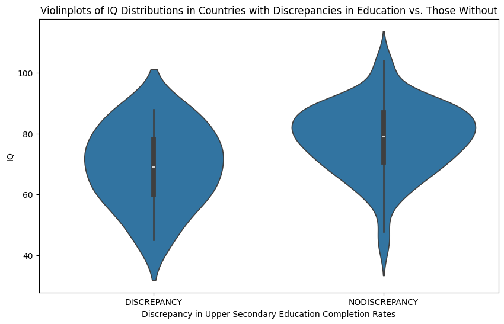

```python
plt.figure(figsize=(10,6))
sns.violinplot(x='Upper_Secondary_Discrepancy', y='IQ', data = composite_df[composite_df['Upper_Secondary_Discrepancy'] != "MISSING"])
plt.xlabel('Discrepancy in Upper Secondary Education Completion Rates')
plt.ylabel('IQ')
plt.title('Violinplots of IQ Distributions in Countries with Discrepancies in Education vs. Those Without')
plt.show()
```

Interestingly, the center of the IQs for the countries with no discrepancy in educating their genders is significantly higher. This means, on average, countries educating both genders more equally have smarter populations compared to those who have a discrepancy. It's notable that both distributions are uniform and fairly normal as well as unimodal, so the actual distributions aren't too different, but their centers are.

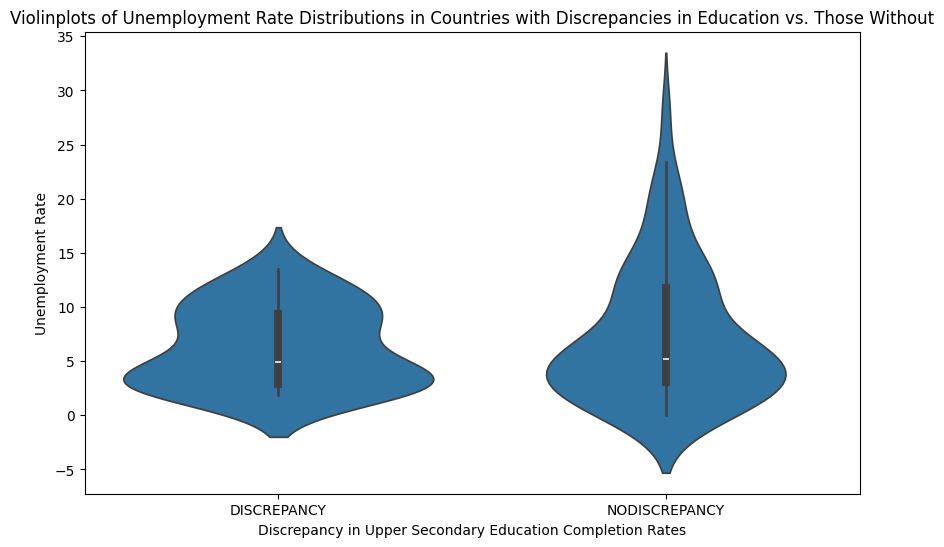

```python
plt.figure(figsize=(10,6))
sns.violinplot(x='Upper_Secondary_Discrepancy', y='Unemployment_Rate', data = composite_df[composite_df['Upper_Secondary_Discrepancy'] != "MISSING"])
plt.xlabel('Discrepancy in Upper Secondary Education Completion Rates')
plt.ylabel('Unemployment Rate')
plt.title('Violinplots of Unemployment Rate Distributions in Countries with Discrepancies in Education vs. Those Without')
plt.show()
```

Observe that unlike the preceding violin plot, there doesn't appear to be a significant difference between the centers for countries with an educational discrepancy vs those without the discrepancy. This indicates that unemployment rates are likely independent of the disparity between male and female seondary education completion rates. This may also be due to the fact that not all jobs require a certain level of education, and the presence of unskilled jobs mitigates the potential effect of the educational disparity.

## Analysis, Hypothesis Testing, and ML

### Hypothesis Test 1: The relationship between Unemployment Rates and the Percent of GDP Spent on Education

We saw in the Exploratory Data Analysis section that Graph 8 was a scatter plot of Unemployment Rate vs. Percent of GDP Spent on Education. We want to explore the significance of this relationship because the graph appears that there could be a potential relationship between the two variables.

Here are our null and alternate hypotheses:

H0: There is no relationship between Unemployment Rate and the Percentage of GDP Spent on Education

H1: There is a relationship between Unemployment Rate and the Percentage of GDP Spent on Education

Let's run an ordinary least squares (OLS) regression between Unemployment Rate and Percent GDP Spent on Education to examine the significance of this relationship.

```python
# only include and plot countries where the unemployment rate data exists (not equal to 0)
nonzero_unemployment_countries = composite_df[composite_df['Unemployment_Rate'] != 0]

ols_results = statsmodels.formula.api.ols(formula="Unemployment_Rate ~ Percent_GDP_Education", data=nonzero_unemployment_countries).fit()
print(ols_results.summary())
```

```
                            OLS Regression Results
==============================================================================
Dep. Variable:      Unemployment_Rate   R-squared:                       0.018
Model:                            OLS   Adj. R-squared:                  0.012
Method:                 Least Squares   F-statistic:                     2.972
Date:                Sat, 04 May 2024   Prob (F-statistic):             0.0866
Time:                        19:01:55   Log-Likelihood:                -489.71
No. Observations:                 163   AIC:                             983.4
Df Residuals:                     161   BIC:                             989.6
Df Model:                           1
Covariance Type:            nonrobust
=========================================================================================
                            coef    std err          t      P>|t|      [0.025      0.975]
-----------------------------------------------------------------------------------------
Intercept                 5.1116      1.013      5.044      0.000       3.110       7.113
Percent_GDP_Education    35.2432     20.443      1.724      0.087      -5.127      75.613
==============================================================================
Omnibus:                       44.598   Durbin-Watson:                   1.753
Prob(Omnibus):                  0.000   Jarque-Bera (JB):               77.162
Skew:                           1.353   Prob(JB):                     1.76e-17
Kurtosis:                       5.009   Cond. No.                         53.3
==============================================================================

Notes:
[1] Standard Errors assume that the covariance matrix of the errors is correctly specified.
```

According to the results of the OLS regression, we fail to reject the null hypothesis that there is no relationship between Unemployment Rate and the Percentage of GDP Spent on Education. Looking at the p-value associated with Percent GDP Education variable, since that value is 0.087, it is larger than a 0.05 alpha value. This means that the relationship between Unemployment Rate and the Percentage of GDP Spent on Education is NOT statistically significant, and thus we fail to reject the null hypothesis.

As a result, it seems that there is no correlation between unemployment rate and percent of GDP spent on education. That's why it's important to not only look at graphs, but conduct statistical analysis to either affirm or disprove a correlationn.

## Analysis, Hypothesis Testing, and ML

### Hypothesis Test 2: The relationship between IQ and Gross Tertiary Education Enrollment

Another relationship that appeared to have some potential significance is IQ and Gross Tertiary Education Enrollment. Unlike Gross Primary Education Enrollment, Tertiary Education Enrollment appeared to have some positive correlation (according to Graph 4 in Exploratory Data Analysis). So, let's perform another OLS regression to examine the relationship between these two variables.

Here are our null and alternate hypotheses:

H0: There is no relationship between IQ and the Gross Tertiary Education Enrollment

H1: There is a relationship between IQ and the Gross Tertiary Education Enrollment

```python
# only include and plot countries where the gross tertiary education enrollment data exists (not equal to 0)
nonzero_education_enrollment_countries = composite_df[composite_df['Gross_Tertiary_Education_Enrollment'] != 0]

ols_results = statsmodels.formula.api.ols(formula="IQ ~ Gross_Tertiary_Education_Enrollment", data=nonzero_education_enrollment_countries).fit()
print(ols_results.summary())
```

```
                            OLS Regression Results
==============================================================================
Dep. Variable:                     IQ   R-squared:                       0.416
Model:                            OLS   Adj. R-squared:                  0.413
Method:                 Least Squares   F-statistic:                     118.3
Date:                Sat, 04 May 2024   Prob (F-statistic):           3.87e-21
Time:                        19:01:55   Log-Likelihood:                -632.22
No. Observations:                 168   AIC:                             1268.
Df Residuals:                     166   BIC:                             1275.
Df Model:                           1
Covariance Type:            nonrobust
=======================================================================================================
                                          coef    std err          t      P>|t|      [0.025      0.975]
-------------------------------------------------------------------------------------------------------
Intercept                              70.1482      1.334     52.594      0.000      67.515      72.781
Gross_Tertiary_Education_Enrollment     0.2963      0.027     10.875      0.000       0.243       0.350
==============================================================================
Omnibus:                        9.481   Durbin-Watson:                   2.032
Prob(Omnibus):                  0.009   Jarque-Bera (JB):                9.506
Skew:                          -0.518   Prob(JB):                      0.00863
Kurtosis:                       3.534   Cond. No.                         80.7
==============================================================================

Notes:
[1] Standard Errors assume that the covariance matrix of the errors is correctly specified.
```

Here, the results of this OLS regression differ from our first test. If we examine the p-value associated with the Gross_Tertiary_Education_Enrollment variable, it is 0.000. Since this p-value is much smaller than an alpha value of 0.05, the relationship between IQ and Gross Tertiary Education Enrollment is statistically significant.

Thus, we can conclude that there is some correlation between the two variables. So, when comparing Test 1 and Test 2, we can also conclude that the relationship between IQ and Gross Tertiary Education Enrollment is stronger than the relationship of Unemployment Rate and the Percentage of GDP Spent on Education.

## Analysis, Hypothesis Testing, and ML

### Hypothesis Test 3: An interaction model between IQ and an interaction of Percent of GDP Spent on Education and Continent

It's also important to consider the interaction between variables that may influence IQ in our analysis. Take the interaction between Percent of GDP Spent on Education and Continent for example. Let's run another OLS regression and examine the results.

Again, here are our null and alternate hypotheses respectively:

H0: There is no relationship between IQ and the interaction of Percent of GDP Spent on Education and Continent.

H1: There is a relationship between IQ and the interaction of Percent of GDP Spent on Education and Continent.

```python
ols_results = statsmodels.formula.api.ols(formula="IQ ~ Percent_GDP_Education:Continent", data=composite_df).fit()
print(ols_results.summary())
```

```
                            OLS Regression Results
==============================================================================
Dep. Variable:                     IQ   R-squared:                       0.508
Model:                            OLS   Adj. R-squared:                  0.491
Method:                 Least Squares   F-statistic:                     29.48
Date:                Sat, 04 May 2024   Prob (F-statistic):           4.28e-24
Time:                        19:01:55   Log-Likelihood:                -652.08
No. Observations:                 178   AIC:                             1318.
Df Residuals:                     171   BIC:                             1340.
Df Model:                           6
Covariance Type:            nonrobust
==================================================================================================================
                                                     coef    std err          t      P>|t|      [0.025      0.975]
------------------------------------------------------------------------------------------------------------------
Intercept                                         77.9825      1.970     39.575      0.000      74.093      81.872
Percent_GDP_Education:Continent[Africa]         -188.5490     46.583     -4.048      0.000    -280.501     -96.597
Percent_GDP_Education:Continent[Asia]            151.5807     55.027      2.755      0.007      42.961     260.201
Percent_GDP_Education:Continent[Europe]          330.1928     47.590      6.938      0.000     236.253     424.133
Percent_GDP_Education:Continent[North America]   -35.2541     55.773     -0.632      0.528    -145.347      74.839
Percent_GDP_Education:Continent[Oceania]          88.9166     40.174      2.213      0.028       9.616     168.218
Percent_GDP_Education:Continent[South America]    97.4157     64.341      1.514      0.132     -29.590     224.421
==============================================================================
Omnibus:                       21.265   Durbin-Watson:                   2.232
Prob(Omnibus):                  0.000   Jarque-Bera (JB):               47.322
Skew:                          -0.516   Prob(JB):                     5.30e-11
Kurtosis:                       5.306   Cond. No.                         133.
==============================================================================

Notes:
[1] Standard Errors assume that the covariance matrix of the errors is correctly specified.
```

That's interesting! According to the OLS regression results, the p-value associated with the interaction between Percent_GDP_Education and Continent changes depending on each continent and its data.

On one hand, the interaction between Percent_GDP_Education and Continent for Africa, Asia, Europe, and Oceania have associated p-values less than an alpha value of 0.05 (0.000, 0.007, 0.000, 0.028 respectively). This means that the relationship between IQ and the interaction is statistically significant. Thus, we can reject the null hypothesis for these continents specifically.

On the other hand, the interaction between Percent_GDP_Education and Continent for the Americas (North America and South America) have associated p-values greater than an alpha value of 0.05 (0.528 and 0.132 respectively). This means that the relationship between IQ and the interaction is NOT statistically significant. Thus, we fail to reject the null hypothesis for these continents specifically.

## Analysis, Hypothesis Testing, and ML

### Multivariate Regression 1: IQ vs Enrollment, Percent GDP, Unemployment Rate

Now, let's try to create a multivariate regression, where we predict IQ based on several other features, such as enrollment rates, percent GDP invested into education, and unemployment rates.

```python
#first, let's remove rows that have missing data
cleaned_df = composite_df[(composite_df['Gross_Primary_Education_Enrollment'] != 0)
                          & (composite_df['Gross_Tertiary_Education_Enrollment'] != 0)
                          & (composite_df['Unemployment_Rate'] != 0)]

#upon doing this, we have 160 rows without missing data, a decent amount considering we started with about 178.
len(cleaned_df)
```

```
160
```

Here, we'll store our features in X and our target in y, and use scikitlearn's train_test_split to randomly split the data into 90% training, 10% testing/validation. Since we have a relatively small amount of data to train on, we want to ensure there's enough to train on, so we'll use 90% of our data for training. Note that typically, an 80-20 (training-test) split would be ideal.

We then use this split data to train the Linear Regression and print out the coefficients/intercept.

```python
X = cleaned_df[['Gross_Primary_Education_Enrollment',
                'Gross_Tertiary_Education_Enrollment',
                'Unemployment_Rate',
                'Percent_GDP_Education']]
y = cleaned_df['IQ']

#Observe that we split with random_state=1, which we'll keep consistent throughout our ML section so
#we can accurately comment on and compare our models
#Note that this is not necessarily best practice in the real world, but we will do so for consistency.
X_train, X_test, y_train, y_test = train_test_split(X, y, test_size=0.1, random_state=1)
firstmod1 = LinearRegression()
firstmod1.fit(X_train, y_train)
print(f'Coefficients (Gross_Primary_Education_Enrollment, Gross_Tertiary_Education_Enrollment, Unemployment_Rate, Percent_GDP_Education): {firstmod1.coef_}')
print(f'Intercept: {firstmod1.intercept_}')
```

```
Coefficients (Gross_Primary_Education_Enrollment, Gross_Tertiary_Education_Enrollment, Unemployment_Rate, Percent_GDP_Education): [ -0.07499135   0.31082261  -0.36704666 -59.20267916]
Intercept: 82.81716092126408
```

We'll now use this trained model to predict y values (y_pred), then test them against the true y values (y_test).

```python
y_pred = firstmod1.predict(X_test)

mse = mean_squared_error(y_test, y_pred)
print('MSE: ' + str(mse))
```

```
MSE: 76.62946540850842
```

```python
#Here we'll analyze a model trained on the same data but using the statsmodels library
#in order to take a closer look at the parameters
firstmod2 = statsmodels.formula.api.ols(formula='IQ ~ Gross_Primary_Education_Enrollment + Gross_Tertiary_Education_Enrollment + Percent_GDP_Education + Unemployment_Rate', data=cleaned_df).fit()
print(firstmod2.summary())
```

```
                            OLS Regression Results
==============================================================================
Dep. Variable:                     IQ   R-squared:                       0.488
Model:                            OLS   Adj. R-squared:                  0.475
Method:                 Least Squares   F-statistic:                     36.92
Date:                Sat, 04 May 2024   Prob (F-statistic):           1.16e-21
Time:                        19:01:56   Log-Likelihood:                -593.18
No. Observations:                 160   AIC:                             1196.
Df Residuals:                     155   BIC:                             1212.
Df Model:                           4
Covariance Type:            nonrobust
=======================================================================================================
                                          coef    std err          t      P>|t|      [0.025      0.975]
-------------------------------------------------------------------------------------------------------
Intercept                              78.7698      6.717     11.726      0.000      65.501      92.039
Gross_Primary_Education_Enrollment     -0.0481      0.064     -0.747      0.456      -0.175       0.079
Gross_Tertiary_Education_Enrollment     0.3250      0.028     11.445      0.000       0.269       0.381
Percent_GDP_Education                 -44.3709     50.821     -0.873      0.384    -144.763      56.021
Unemployment_Rate                      -0.3916      0.165     -2.375      0.019      -0.717      -0.066
==============================================================================
Omnibus:                       13.001   Durbin-Watson:                   2.081
Prob(Omnibus):                  0.002   Jarque-Bera (JB):               15.128
Skew:                          -0.568   Prob(JB):                     0.000519
Kurtosis:                       3.988   Cond. No.                     7.16e+03
==============================================================================

Notes:
[1] Standard Errors assume that the covariance matrix of the errors is correctly specified.
[2] The condition number is large, 7.16e+03. This might indicate that there are
strong multicollinearity or other numerical problems.
```

That's quite a large mean squared error, implying that we're on average plus or minus 8.71 IQ points from the true value. We also have quite a low r-squared of .488 and hence a low correlation. Let's see if we can improve our model.

Observe that our R-squared for this model is 0.488, meaning that our current independent variables only account for 48.8% of the variance in IQ, which is not great.

## Analysis, Hypothesis Testing, and ML

### Multivariate Regession 2: IQ vs Enrollment, Percent GDP, Unemployment Rate, Latitude, Longitude

Observe that we haven't worked with Latitude or Longitude yet, so let's see if bringing them in as independent variables decreases our MSE and increases our r-squared, as this might be a "hidden" correlation that we haven't yet discovered.

```python
X = cleaned_df[['Gross_Primary_Education_Enrollment',
                'Gross_Tertiary_Education_Enrollment',
                'Unemployment_Rate',
                'Latitude',
                'Longitude',
                'Percent_GDP_Education']]
y = cleaned_df['IQ']

X_train, X_test, y_train, y_test = train_test_split(X, y, test_size=0.1, random_state=1)
secondmod1 = LinearRegression()
secondmod1.fit(X_train, y_train)
print(secondmod1.coef_)
print(secondmod1.intercept_)
```

```
[-5.26350721e-02  1.84187010e-01 -2.24293369e-01  3.68411419e-01
  8.10162663e-02 -9.98887018e+01]
72.33588334479897
```

```python
y_pred = secondmod1.predict(X_test)

mse = mean_squared_error(y_test, y_pred)
print('MSE: ' + str(mse))
```

```
MSE: 49.80184279139307
```

```python
secondmod2 = statsmodels.formula.api.ols(formula='IQ ~ Gross_Primary_Education_Enrollment + Gross_Tertiary_Education_Enrollment + Percent_GDP_Education + Unemployment_Rate + Latitude + Longitude', data=cleaned_df).fit()
print(secondmod2.summary())
```

```
                            OLS Regression Results
==============================================================================
Dep. Variable:                     IQ   R-squared:                       0.624
Model:                            OLS   Adj. R-squared:                  0.610
Method:                 Least Squares   F-statistic:                     42.37
Date:                Sat, 04 May 2024   Prob (F-statistic):           3.60e-30
Time:                        19:01:56   Log-Likelihood:                -568.40
No. Observations:                 160   AIC:                             1151.
Df Residuals:                     153   BIC:                             1172.
Df Model:                           6
Covariance Type:            nonrobust
=======================================================================================================
                                          coef    std err          t      P>|t|      [0.025      0.975]
-------------------------------------------------------------------------------------------------------
Intercept                              69.7329      5.917     11.786      0.000      58.044      81.422
Gross_Primary_Education_Enrollment     -0.0409      0.056     -0.731      0.466      -0.151       0.070
Gross_Tertiary_Education_Enrollment     0.1937      0.031      6.215      0.000       0.132       0.255
Percent_GDP_Education                 -78.0059     44.582     -1.750      0.082    -166.082      10.070
Unemployment_Rate                      -0.2400      0.144     -1.661      0.099      -0.525       0.045
Latitude                                0.3633      0.055      6.665      0.000       0.256       0.471
Longitude                               0.0859      0.018      4.897      0.000       0.051       0.121
==============================================================================
Omnibus:                       37.788   Durbin-Watson:                   2.064
Prob(Omnibus):                  0.000   Jarque-Bera (JB):               90.526
Skew:                          -0.988   Prob(JB):                     2.20e-20
Kurtosis:                       6.110   Cond. No.                     8.26e+03
==============================================================================

Notes:
[1] Standard Errors assume that the covariance matrix of the errors is correctly specified.
[2] The condition number is large, 8.26e+03. This might indicate that there are
strong multicollinearity or other numerical problems.
```

Observe that we see substantial improvements when adding Latitude and Longitude. Our MSE has decreased to 49, so our predictions are plus or minus 7 IQ points. Our correlation parameter (r-squared) has also shot up to .624, meaning our independent variables (same as earlier but with Latitude and Longitudde factored in), explain 62.4% percent of the variance in IQ.

Why don't we take a moment to look more closely at latitude and longitude.

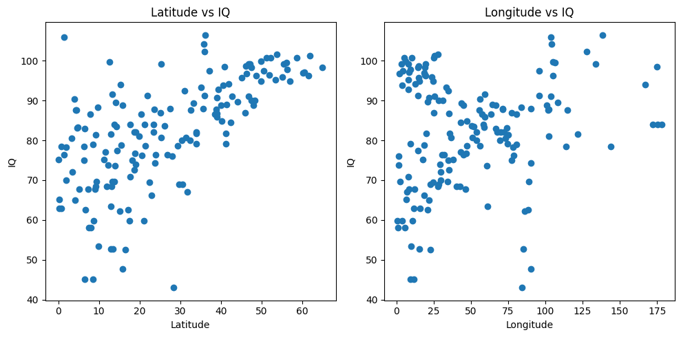

```python
fig, axs = plt.subplots(1, 2, figsize=(10,5))

axs[0].scatter(cleaned_df['Latitude'], cleaned_df['IQ'])
axs[0].set_xlabel('Latitude')
axs[0].set_ylabel('IQ')
axs[0].set_title('Latitude vs IQ')

axs[1].scatter(cleaned_df['Longitude'], cleaned_df['IQ'])
axs[1].set_xlabel('Longitude')
axs[1].set_ylabel('IQ')
axs[1].set_title('Longitude vs IQ')

plt.tight_layout()
plt.show()
```

The clear clustering in the graphs, in combination with the decrease in MSE and increase in correlation reinforces the idea that Latitude and Longitude have some influence on IQ.

Logically, this can be rationalized through similarities in policy, culture, values, and education in neighboring countries. Given this logical approach, wouldn't it also make sense to add interactions with continents in our model then?

## Analysis, Hypothesis Testing, and ML

### Multivariate Regression 3: IQ vs Enrollment, Percent GDP, Unemployment Rate, Latitude, Longitude (but with interactions!)

Observe that there's some information inherently related to location/continent, so let's add interactions with the Continent feature for some of our existing independent variables.

[figure not shown]

```python
thirdmod = statsmodels.formula.api.ols(formula='IQ ~ Gross_Primary_Education_Enrollment + Gross_Tertiary_Education_Enrollment + Percent_GDP_Education:Continent + Unemployment_Rate:Continent + Latitude:Continent + Longitude:Continent', data=cleaned_df).fit()
print(thirdmod.summary())
```

```
                            OLS Regression Results
==============================================================================
Dep. Variable:                     IQ   R-squared:                       0.733
Model:                            OLS   Adj. R-squared:                  0.681
Method:                 Least Squares   F-statistic:                     14.04
Date:                Sat, 04 May 2024   Prob (F-statistic):           9.02e-27
Time:                        19:01:56   Log-Likelihood:                -541.10
No. Observations:                 160   AIC:                             1136.
Df Residuals:                     133   BIC:                             1219.
Df Model:                          26
Covariance Type:            nonrobust
==================================================================================================================
                                                     coef    std err          t      P>|t|      [0.025      0.975]
------------------------------------------------------------------------------------------------------------------
Intercept                                         69.1706      5.659     12.223      0.000      57.977      80.364
Gross_Primary_Education_Enrollment                -0.0629      0.052     -1.200      0.232      -0.167       0.041
Gross_Tertiary_Education_Enrollment                0.1502      0.037      4.060      0.000       0.077       0.223
Percent_GDP_Education:Continent[Africa]          -66.0903     65.004     -1.017      0.311    -194.665      62.484
Percent_GDP_Education:Continent[Asia]            -41.8837     75.335     -0.556      0.579    -190.892     107.125
Percent_GDP_Education:Continent[Europe]           98.6611    128.745      0.766      0.445    -155.991     353.313
Percent_GDP_Education:Continent[North America]   -45.4993    113.677     -0.400      0.690    -270.349     179.350
Percent_GDP_Education:Continent[Oceania]        -161.1685    214.274     -0.752      0.453    -584.994     262.657
Percent_GDP_Education:Continent[South America]   235.9057    213.604      1.104      0.271    -186.596     658.407
Unemployment_Rate:Continent[Africa]               -0.2518      0.222     -1.132      0.260      -0.692       0.188
Unemployment_Rate:Continent[Asia]                  0.3482      0.366      0.950      0.344      -0.377       1.073
Unemployment_Rate:Continent[Europe]               -0.1816      0.336     -0.541      0.590      -0.846       0.483
Unemployment_Rate:Continent[North America]         0.5690      0.324      1.758      0.081      -0.071       1.209
Unemployment_Rate:Continent[Oceania]               0.3283      1.394      0.235      0.814      -2.430       3.087
Unemployment_Rate:Continent[South America]         0.4524      0.825      0.548      0.584      -1.179       2.084
Latitude:Continent[Africa]                         0.2622      0.159      1.652      0.101      -0.052       0.576
Latitude:Continent[Asia]                           0.1182      0.091      1.300      0.196      -0.062       0.298
Latitude:Continent[Europe]                         0.3898      0.153      2.542      0.012       0.087       0.693
Latitude:Continent[North America]                  0.6770      0.203      3.333      0.001       0.275       1.079
Latitude:Continent[Oceania]                        0.2614      0.411      0.635      0.526      -0.552       1.075
Latitude:Continent[South America]                 -0.0879      0.194     -0.454      0.651      -0.471       0.295
Longitude:Continent[Africa]                        0.2372      0.077      3.073      0.003       0.085       0.390
Longitude:Continent[Asia]                          0.1740      0.035      4.948      0.000       0.104       0.244
Longitude:Continent[Europe]                       -0.0617      0.117     -0.526      0.600      -0.294       0.170
Longitude:Continent[North America]                -0.0955      0.095     -1.006      0.316      -0.283       0.092
Longitude:Continent[Oceania]                       0.1367      0.066      2.068      0.041       0.006       0.267
Longitude:Continent[South America]                 0.0147      0.122      0.120      0.904      -0.227       0.257
==============================================================================
Omnibus:                       41.623   Durbin-Watson:                   2.089
Prob(Omnibus):                  0.000   Jarque-Bera (JB):              119.315
Skew:                          -1.016   Prob(JB):                     1.23e-26
Kurtosis:                       6.711   Cond. No.                     4.00e+04
==============================================================================

Notes:
[1] Standard Errors assume that the covariance matrix of the errors is correctly specified.
[2] The condition number is large,  4e+04. This might indicate that there are
strong multicollinearity or other numerical problems.
```

```python
X = cleaned_df[['Gross_Primary_Education_Enrollment',
                'Gross_Tertiary_Education_Enrollment',
                'Unemployment_Rate',
                'Latitude',
                'Longitude',
                'Percent_GDP_Education',
                'Continent']]
y = cleaned_df[['IQ']]


X_train, X_test, y_train, y_test = train_test_split(X, y, test_size=0.1, random_state=1)

MSE = mean_squared_error(y_test, thirdmod.predict(X_test))
MSE
```

```
43.42925099461695
```

As can be seen above, we have an increase in r-squared to .733, a greater correlation than before upon the addition of our interaction terms. Our model thus accounts for 73.3% of variance in IQ. Thus, we can conclude that of the 3 models created thus far, this is the greatest fit. We also have an MSE of 43, a decent improvement from the previous model.

## Analysis, Hypothesis Testing, and ML

### Decision Trees: IQ vs Enrollment, Percent GDP, Unemployment Rate, Latitude, Longitude

Let's pivot to a different regression method. Perhaps our data can't properly be explained linearly and we should try training a another machine learning model on it. A good regression model to begin with is a Decision Tree that uses the same features as our multivariate linear model.

```python
# the same features that we used in the linear regressor -- only use rows with non missing data (160)
X = composite_df[['Gross_Primary_Education_Enrollment', 'Gross_Tertiary_Education_Enrollment', 'Percent_GDP_Education', 'Unemployment_Rate', 'Latitude', 'Longitude', 'IQ']]
X = X[(X['Gross_Primary_Education_Enrollment'] != 0) & (X['Gross_Tertiary_Education_Enrollment'] != 0) & (X['Percent_GDP_Education'] != 0) & (X['Unemployment_Rate'] != 0)]

y = X['IQ']
X.drop(['IQ'], axis=1, inplace=True)
```

```python
# split into training and testing sets -- keep same random seed from multivariate regression
X_train, X_test, y_train, y_test = train_test_split(X, y, test_size=0.1,random_state=1)
```

```python
# fit to a decision tree -- let's arbitrarily pick random seed 50, again to make sure consistency in our markdown
model_decisiontree = DecisionTreeRegressor(random_state=50)
model_decisiontree.fit(X_train, y_train)
```

```
DecisionTreeRegressor(random_state=50)
```

```python
# get the mean squared error on the test data
y_pred = model_decisiontree.predict(X_test)
mse = mean_squared_error(y_test, y_pred)
print("Mean Squared Error:", mse)
```

```
Mean Squared Error: 83.75559375000003
```

Okay, we observe that it's worse than the linear model. Before we dive into why or try to improve our results, we can actually visualize how complex our tree is.

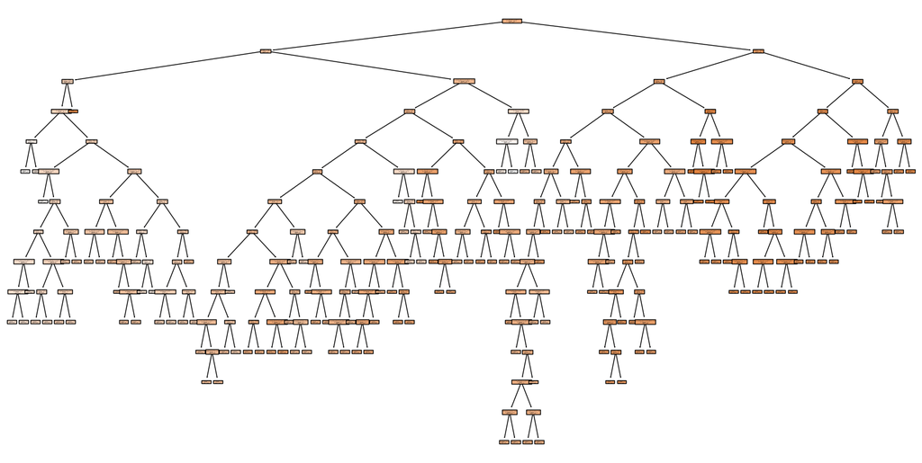

```python
plt.figure(figsize=(20,10))
plot_tree(model_decisiontree, feature_names=X.columns, filled=True)
plt.show()
```

```python
model_decisiontree.score(X_train, y_train)
```

```
1.0
```

With a decision tree, we can prevent overfitting using a few hyperparameters provided in sklearn. More specifically, we can use hyperparameters like "max_depth" and "min_samples_leaf" to make sure the tree doesn't have too many levels and each leaf has a specific number of samples, respectively.

```python
# limit max depth to 10 and make sure each leaf has 5 samples minimum
model_decisiontree2 = DecisionTreeRegressor(random_state=50, max_depth=10, min_samples_leaf=5)
model_decisiontree2.fit(X_train, y_train)
```

```
DecisionTreeRegressor(max_depth=10, min_samples_leaf=5, random_state=50)
```

```python
model_decisiontree2.score(X_train, y_train)
```

```
0.7976221232585898
```

```python
# get the mean squared error on the test data
y_pred = model_decisiontree2.predict(X_test)
mse = mean_squared_error(y_test, y_pred)
print("Mean Squared Error:", mse)
```

```
Mean Squared Error: 40.45260542049323
```

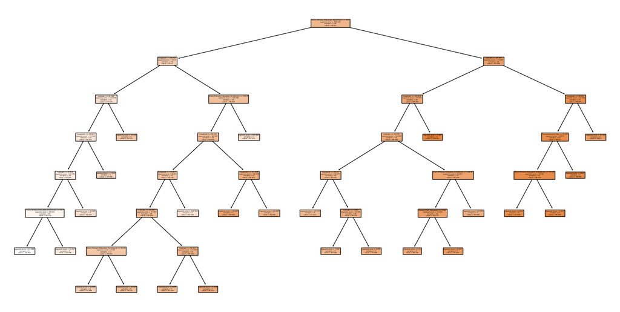

```python
plt.figure(figsize=(20,10))
plot_tree(model_decisiontree2, feature_names=X.columns, filled=True)
plt.show()
```

Also, as expected, a much simpler decision tree. We do have one more regression model to try to see if we can do even better, though.

## Analysis, Hypothesis Testing, and ML

### Random Forest: IQ vs Enrollment, Percent GDP, Unemployment Rate, Latitude, Longitude

[figure not shown]

Something that might work better than 1 Decision Tree regression model is a bunch of them -- that is, a random forest that creates 100 different decision tree models using the same independent variables, constraints (to prevent overfitting), and then averaging out all of their predictions to see if that helps us get a better model.

```python
# the same features (160 rows)
X = composite_df[['Gross_Primary_Education_Enrollment', 'Gross_Tertiary_Education_Enrollment', 'Percent_GDP_Education', 'Unemployment_Rate', 'Latitude', 'Longitude', 'IQ']]
X = X[(X['Gross_Primary_Education_Enrollment'] != 0) & (X['Gross_Tertiary_Education_Enrollment'] != 0) & (X['Percent_GDP_Education'] != 0) & (X['Unemployment_Rate'] != 0)]

y = X['IQ']
X.drop(['IQ'], axis=1, inplace=True)
```

```python
# split into training and testing sets
X_train, X_test, y_train, y_test = train_test_split(X, y, test_size=0.1, random_state=1)
```

```python
# let's keep a constant random state, still 50 (like we had with the last model) and use the same constraints to prevent overfitting
# per decision tree -- also we are using 100 decision trees
model_randomforest = RandomForestRegressor(n_estimators=100, random_state=50, max_depth=10, min_samples_leaf=5)
model_randomforest.fit(X_train, y_train)
```

```
RandomForestRegressor(max_depth=10, min_samples_leaf=5, random_state=50)
```

```python
model_randomforest.score(X_train, y_train)
```

```
0.8283405462159215
```

```python
y_pred = model_randomforest.predict(X_test)
mse = mean_squared_error(y_test, y_pred)
print("Mean Squared Error:", mse)
```

```
Mean Squared Error: 36.62973108418697
```

Wow! So this model does better than the 1 decision tree model. This intuitively makes sense: if one tree can't properly predict IQs, a 100 trees simultaneously making these predictions and then averaging these should perhaps be better -- and it is. Our model doesn't seem overfit, with an R^2 of 0.83. It did really well on our test data as well, with a mean squared error of 36.630 meaning roughly an error of 6.05 IQ points, which with all things considered, is not bad at all.

## Policy and Insight

### Conclusions/Observations

[figure not shown]

Having written this notebook, we’ve gained a greater appreciation for the effect of educational investment on literacy, IQ, and unemployment. We recognize the significance of our findings and hope that they can be used to positively influence educational policy worldwide. More information on the importance of investment can be found in the following article (https://www.csis.org/analysis/investing-quality-education-economic-development-peace-and-stability), one of our inspirations for writing this notebook.

We realized that it’s not as simple as “investing x% more in education increases average IQ by y points”, but rather as a product of several factors, such as continent, unemployment rates, enrollment rates, completion rates, location, and etc. A few of these, namely enrollment rates, completion rates, and unemployment rates, can quite clearly be linked to the country’s investment into education, not as a matter of proportion, but rather the internal allocation of the proportion set aside for education: how much is dedicated towards teachers, how much towards educational technology, how much towards extracurricular programs, how much towards outreach and education for underserved populations? Also, things like completion rates and gross enrollment rates are inherently not only linked to monetary investment into education but also how society in said country views education as a whole. That is, a country’s culture must strongly encourage children to pursue a full secondary education, and hopefully even beyond. Also, their policies must make education unequivocally available to its entire population, regardless of factors like class and gender so that most of their population has the ability and support to make it fully through their schooling system.

### Next Steps

Through an extension of our research, we could likely discover and explain the several economic/spending factors that influence IQ and employment. We could also analyze the intelligence correlation based on other metrics, say IB or PISA scores, considering that IQ has long been a disputed system of measuring intelligence. See the following two articles for conflicting arguments on this matter:

- https://som.yale.edu/news/2009/11/why-high-iq-doesnt-mean-youre-smart - Yale Study that argues that IQ is a bad measure of intelligence
- https://www.science.org/content/article/what-does-iq-really-measure#:~:text=A%20new%20study%20argues%20that%20the%20score%20reflects%20both%20motivation%20and%20intelligence&text=Kids%20who%20score%20higher%20on,even%20greater%20health%2C%20and%20longevity - Science.org Article in favor of IQ as an intelligence metric and as a metric of how motivated a person is

Such a detailed report would provide us with further insight into how countries with low IQ to educational investment efficiencies could learn from other, more “successful” countries’ educational models. We believe this is quite a major issue and that further statistical/data analysis could be a key step towards greater and equitable educational opportunity worldwide.

On that note, it's worth mentioning the plethora of benefits education brings to masses. Although many think it's a matter of just helping a person get a job, there's actually much more to it, as these articles detail:

- https://www.federalreserve.gov/publications/2019-economic-well-being-of-us-households-in-2018-higher-education.htm - A government study that takes the general notion of "the more the education, the higher the salary" a step further by analyzing how fiscally secure people feel
- https://www.uopeople.edu/blog/benefits-of-education-are-societal-and-personal/ - A University of the People article that goes beyond financial matters, talking about the many societal and personal gains a person attains by staying in school

[figure not shown]

So, the next time you're considering not going to school or a class, remember that education is a privilege we're lucky to have, and we should value it.

In the words of Edward St John, "Education has the power to transform lives and provides the foundation for success".